# Preliminary_Data_Analysis

Jessica Brown

2024-03-07

This is the HyperIMU app trial.. We are starting this with the template!! This data is structured differently, so because of that.. many things must be changed. As well as, I didn’t record any uncalibrated data. It’s calibrated or nothing, so let’s see how this turned out.

Rightleg info I have to delete: @ HyperIMU - ianovir @ Date:Thu Mar 21 14:54:29 EDT 2024, Sampling Rate:20ms

LeftArm info likewise: @ HyperIMU - ianovir @ Date:Thu Mar 21 14:54:28 EDT 2024, Sampling Rate:20ms

```r
#Setup
library(readr)
library(ggplot2)
library(forecast)
library(fpp2)
library(TTR)
library(dplyr)
library(lubridate)
library(here)
library(prophet)
library(tsfknn)
library(usethis)
library(devtools)
library(stringr)
library(tidyverse)
library(patchwork)
library(gsignal)
#Making a path for all files to avoid having to write this more than once
path = "C:/Users/TreeP/Downloads/School/ComputerScience(CSCI)/CSCI4950/FinalProject"

#Import all LEFTARMredo data
LEFTARM = read.csv(here(path, "LEFTARM_TEST.csv"))

#Import all RIGHTLEGredo data
RIGHTLEG = read.csv(here(path, "RIGHTLEG_TEST.csv"))
```

Because of how this records timestamps, I must clean this up first into seconds_elapsed.

```r
#I will just minus everything with the first entry to get a relative sense of what the timestamp means:

LEFTARM$seconds_elapsed = LEFTARM$timestamp - LEFTARM["1",]$timestamp

#As the second entry is 112 and the second one is 954003, it's safe to conclude that this means .112 and 954.003 seconds respectively therefor everything will be divided by 1000
LEFTARM$seconds_elapsed = LEFTARM$seconds_elapsed/1000

#Do the same with RIGHTLEG:
RIGHTLEG$seconds_elapsed = (RIGHTLEG$timestamp - RIGHTLEG["1",]$timestamp)/1000
```

Next, we will create labels that tell at which point a dance move is being performed

```r
#Unlike with the training dataset where I recorded each move one at a time consecutively without repeating any move, the dance routine I have made repeats many moves. Therefore I must structure this very different. Unfortunately, we can't have the row name corresponding to the dance number or dance name since that wil result in duplicate row names.. which gives me error. Boohoo.

dance = data.frame(row.names = c(0:41))

dance$order = c("Salsa", "LeftToRight", "Salsa", "Turns", "Salsa", "LeftToRight", "Salsa", "Turns", "KneeUpSideToSide", "KneeUp", "FourCorners", "OneTwoStep", "SwayNoodleArms", "SwayBlockArms", "SideJumpingJacks", "ThtBlondeGirl", "SideJumpingJacks", "ThtBlondeGirl", "SideJumpingJacks", "ThtBlondeGirl", "HoppityHop", "OneTwoThreeUp", "HoppityHop","OneTwoThree", "OneTwoStepCombo", "SwayNoodleArms", "SwayBlockArms", "BabySteps", "SlidyLeg", "BabySteps", "SlidyLeg", "BabySteps", "SlidyLeg", "BabySteps", "SlidyLeg", "HitIt", "LegLegUpDown", "HitIt", "OppaGangnamStyle", "HitIt", "LegLegUpDown", "HitIt")

#Corresponding number of each dance, it's the same as in the trainingset file
dance$number = c(2,13,2,4,2,13,2,4,5,11,8,7,9,1,3,15,3,15,3,15,0,18,0,16,17,9,1,12,20,12,20,12,20,12,20,19,14,19,10,19,14,19)


#Now, we must do the start and stop times just like with the training data
dance$starttime = c(149, 151, 153, 154, 157, 159, 161, 163, 165, 171, 179, 190, 196, 199, 205, 207, 210, 212, 215, 217, 220, 222, 226, 227.5, 232.5, 246, 253, 259.5, 262, 263, 265.5, 267.5, 269, 270.5, 272.5, 274.5, 278, 283, 286.5, 292, 296, 301)

dance$stoptime = c(151, 153, 154, 157, 159, 161, 163, 165, 171, 179, 190, 196, 199, 205, 207, 210, 212, 215, 217, 220, 222, 226, 227.5, 232.5, 246, 253, 259.5, 262, 263, 265.5, 267.5, 269, 270.5, 272.5, 274.5, 278, 283, 286.5, 292, 296, 301, 303.5)

#My numbers are slightly off depending on rightleg vs leftarm. I count both to 353.5 seconds.. Let's fix that:
dance$starttime = dance$starttime + (((355.049 + 355.14)/2) - 353.5)
dance$stoptime = dance$stoptime + (((355.049 + 355.14)/2) - 353.5)


#Now we will actually assign the numbers to each data entry..

#This beyond gorgeous loop simply assigns every entry that has a seconds_elapsed value within the starttime-stoptime parameters its corresponding dance label. I use my dancebynames and dancebynumbers dataframes to iterate through every dance move. It is much more effective than doing every single dataframe for every dance move. This would be 2*41 or 82 explicit assignments. Instead every dataframe appears once and the assignment is done through reference variables. Much better.

for (x in 0:41){
yeah = as.character(x)

LEFTARM$dance[(LEFTARM$seconds_elapsed < dance[yeah,]$stoptime) & (LEFTARM$seconds_elapsed >= dance[yeah,]$starttime)] = dance[yeah,]$number

RIGHTLEG$dance[(RIGHTLEG$seconds_elapsed < dance[yeah,]$stoptime) & (RIGHTLEG$seconds_elapsed >= dance[yeah,]$starttime)] = dance[yeah,]$number
}
```

Get rid of the unneeded data. I am removing the data where I am not dancing. Only when I pressed record to when I started dancing & when I stopped dancing till when I stopped recording will be deleted. No data in the middle is deleted. I believe that that is unnecessary complicated.

```r
#Subset all values with no dancing.

LEFTARM = LEFTARM[(is.na(LEFTARM$dance) > 0) == FALSE,]

RIGHTLEG = RIGHTLEG[(is.na(RIGHTLEG$dance) > 0) == FALSE,]
```

Now, we will manually calibrate it aka finding the average of x, y, z, and then subtracting that average. This will be very messy, so just know that it’s general calibration.

I believe this data is already calibrated, so we will gray everything else unless we learn otherwise.

```r
#LEFTARM's turn first
#LEFTARMredo_accuncal$x = (LEFTARMredo_accuncal$x - mean(LEFTARMredo_accuncal$x))
#LEFTARMredo_accuncal$z = (LEFTARMredo_accuncal$z - mean(LEFTARMredo_accuncal$z))
#LEFTARMredo_accuncal$y = (LEFTARMredo_accuncal$y - mean(LEFTARMredo_accuncal$y))

#LEFTARMredo_gyrouncal$x = (LEFTARMredo_gyrouncal$x - mean(LEFTARMredo_gyrouncal$x))
#LEFTARMredo_gyrouncal$z = (LEFTARMredo_gyrouncal$z - mean(LEFTARMredo_gyrouncal$z))
#LEFTARMredo_gyrouncal$y = (LEFTARMredo_gyrouncal$y - mean(LEFTARMredo_gyrouncal$y))

#LEFTARMredo_maguncal$x = (LEFTARMredo_maguncal$x - mean(LEFTARMredo_maguncal$x))
#LEFTARMredo_maguncal$z = (LEFTARMredo_maguncal$z - mean(LEFTARMredo_maguncal$z))
#LEFTARMredo_maguncal$y = (LEFTARMredo_maguncal$y - mean(LEFTARMredo_maguncal$y))


#Now it's time for RIGHTLEG calibration
#RIGHTLEGredo_acc$x = (RIGHTLEGredo_acc$x - mean(RIGHTLEGredo_acc$x))
#RIGHTLEGredo_acc$z = (RIGHTLEGredo_acc$z - mean(RIGHTLEGredo_acc$z))
#RIGHTLEGredo_acc$y = (RIGHTLEGredo_acc$y - mean(RIGHTLEGredo_acc$y))

#RIGHTLEGredo_gyrouncal$x = (RIGHTLEGredo_gyrouncal$x - mean(RIGHTLEGredo_gyrouncal$x))
#RIGHTLEGredo_gyrouncal$z = (RIGHTLEGredo_gyrouncal$z - mean(RIGHTLEGredo_gyrouncal$z))
#RIGHTLEGredo_gyrouncal$y = (RIGHTLEGredo_gyrouncal$y - mean(RIGHTLEGredo_gyrouncal$y))

#RIGHTLEGredo_maguncal$x = (RIGHTLEGredo_maguncal$x - mean(RIGHTLEGredo_maguncal$x))
#RIGHTLEGredo_maguncal$z = (RIGHTLEGredo_maguncal$z - mean(RIGHTLEGredo_maguncal$z))
#RIGHTLEGredo_maguncal$y = (RIGHTLEGredo_maguncal$y - mean(RIGHTLEGredo_maguncal$y))
```

It is time to plot everything!!!!!

```r
#Plotting
laap = ggplot(data = LEFTARM) + geom_line(aes(x = seconds_elapsed, y = accelerometer_x), color = "#999999") + geom_line(aes(x = seconds_elapsed, y = accelerometer_y), color = "#E69F00") + geom_line(aes(x = seconds_elapsed, y = accelerometer_z), color = "#56B4E9") + labs(y = "",title = "LeftArm Accelerometer")

lagp = ggplot(data = LEFTARM) + geom_line(aes(x = seconds_elapsed, y = gyroscope_x), color = "#999999") + geom_line(aes(x = seconds_elapsed, y = gyroscope_y), color = "#E69F00") + geom_line(aes(x = seconds_elapsed, y = gyroscope_z), color = "#56B4E9") + labs(y = "",title = "LeftArm Gyroscope")

lamp = ggplot(data = LEFTARM) + geom_line(aes(x = seconds_elapsed, y = magnetometer_x), color = "#999999") + geom_line(aes(x = seconds_elapsed, y = magnetometer_y), color = "#E69F00") + geom_line(aes(x = seconds_elapsed, y = magnetometer_z), color = "#56B4E9") + labs(y = "",title = "LeftArm Magnetometer")

rlap = ggplot(data = RIGHTLEG) + geom_line(aes(x = seconds_elapsed, y = accelerometer_x), color = "#999999") + geom_line(aes(x = seconds_elapsed, y = accelerometer_y), color = "#E69F00") + geom_line(aes(x = seconds_elapsed, y = accelerometer_z), color = "#56B4E9") + labs(y = "",title = "RightLeg Accelerometer")

rlgp = ggplot(data = RIGHTLEG) + geom_line(aes(x = seconds_elapsed, y = gyroscope_x), color = "#999999") + geom_line(aes(x = seconds_elapsed, y = gyroscope_y), color = "#E69F00") + geom_line(aes(x = seconds_elapsed, y = gyroscope_z), color = "#56B4E9") + labs(y = "",title = "RightLeg Gyroscope")

rlmp = ggplot(data = RIGHTLEG) + geom_line(aes(x = seconds_elapsed, y = magnetometer_x), color = "#999999") + geom_line(aes(x = seconds_elapsed, y = magnetometer_y), color = "#E69F00") + geom_line(aes(x = seconds_elapsed, y = magnetometer_z), color = "#56B4E9") + labs(y = "",title = "RightLeg Magnetometer")
```

We will put all these graphs together as one big graph

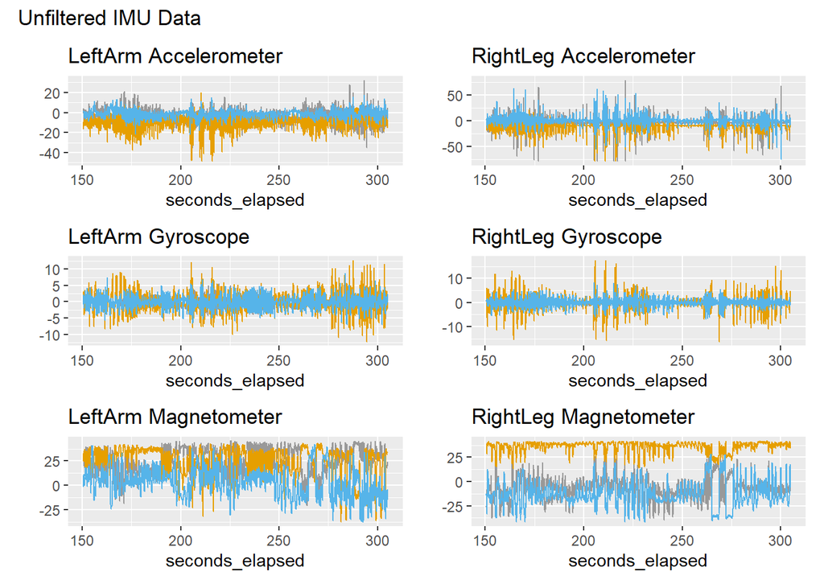

```r
patch = (laap + rlap)/(lagp + rlgp)/(lamp + rlmp)
patch + plot_annotation(title = "Unfiltered IMU Data")
```

Before I filter any noise, I need to combine x, y, and z into a succinct single line instead of 3 separate ones.

```r
#We will do this by doing sqrt(x^2 + y^2 + z^2)

LEFTARM$acc_combined = sqrt(LEFTARM$accelerometer_x^2 + LEFTARM$accelerometer_y^2 + LEFTARM$accelerometer_z^2)

LEFTARM$gyro_combined = sqrt(LEFTARM$gyroscope_x^2 + LEFTARM$gyroscope_y^2 + LEFTARM$gyroscope_z^2)

LEFTARM$mag_combined = sqrt(LEFTARM$magnetometer_x^2 + LEFTARM$magnetometer_y^2 + LEFTARM$magnetometer_z^2)

RIGHTLEG$acc_combined = sqrt(RIGHTLEG$accelerometer_x^2 + RIGHTLEG$accelerometer_y^2 + RIGHTLEG$accelerometer_z^2)

RIGHTLEG$gyro_combined = sqrt(RIGHTLEG$gyroscope_x^2 + RIGHTLEG$gyroscope_y^2 + RIGHTLEG$gyroscope_z^2)

RIGHTLEG$mag_combined = sqrt(RIGHTLEG$magnetometer_x^2 + RIGHTLEG$magnetometer_y^2 + RIGHTLEG$magnetometer_z^2)
```

This must be graphed.

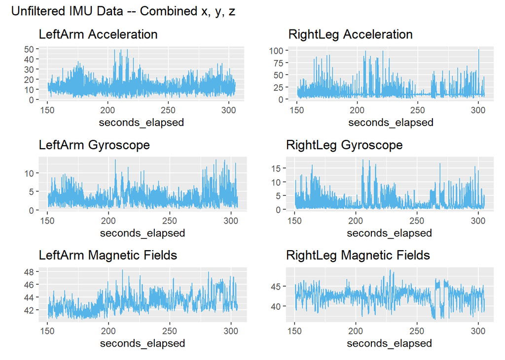

```r
lagcp = ggplot(data = LEFTARM) + geom_line(aes(x = seconds_elapsed, y = gyro_combined), color = "#56B4E9") + labs(y = "",title = "LeftArm Gyroscope")

rlgcp = ggplot(data = RIGHTLEG) + geom_line(aes(x = seconds_elapsed, y = gyro_combined), color = "#56B4E9") + labs(y = "",title = "RightLeg Gyroscope")

laacp = ggplot(data = LEFTARM) + geom_line(aes(x = seconds_elapsed, y = acc_combined), color = "#56B4E9") + labs(y = "",title = "LeftArm Acceleration")

rlacp = ggplot(data = RIGHTLEG) + geom_line(aes(x = seconds_elapsed, y = acc_combined), color = "#56B4E9") + labs(y = "",title = "RightLeg Acceleration")

lamcp = ggplot(data = LEFTARM) + geom_line(aes(x = seconds_elapsed, y = mag_combined), color = "#56B4E9") + labs(y = "",title = "LeftArm Magnetic Fields")

rlmcp = ggplot(data = RIGHTLEG) + geom_line(aes(x = seconds_elapsed, y = mag_combined), color = "#56B4E9") + labs(y = "",title = "RightLeg Magnetic Fields")

combinedpatch = (laacp + rlacp)/(lagcp + rlgcp)/(lamcp + rlmcp)
combinedpatch + plot_annotation(title = "Unfiltered IMU Data -- Combined x, y, z")
```

I am just deleting all these graphs now along with leftover variables. It takes up space, and it makes my interface look messy. R doesn’t have a garbage collector. We must delete manually.

```r
remove(laap)
remove(lagp)
remove(lamp)
remove(rlap)
remove(rlgp)
remove(rlmp)
remove(cur)
remove(x)
remove(yeah)
```

We need to filter noise.

```r
# Define parameters
#We have a total of 154 seconds (149 to 303.5) captured. Both were done at a rate of 20ms or 50Hz, yet we have roughly 28 hertz for the arm (4314/154) and 40 Hz for the leg (6193/154). For this reason, we will have slightly different filters for each

order = 2  # Adjust as needed, 4 is seen as the best starting point

fsarm = 28
fsleg = 40

cutoff = 1  # Cutoff frequency (Hz) - adjust but it's best to stay at or under area of interest. I will say 1 second because I doubt I will do a window-size of less than 1 second

# Calculate Nyquist frequency, I believe this is supposed to stay at .5*fs
nyqarm = 0.5 * fsarm
nyqleg = 0.5 * fsleg

# Normalize the cutoff frequency
normal_cutoffarm = cutoff / nyqarm
normal_cutoffleg = cutoff / nyqleg

buttarm = butter(order, normal_cutoffarm, type = "low")
buttleg = butter(order, normal_cutoffleg, type = "low")

#Now we will create a filtered col in each dataframe
LEFTARM$acc_combinedf = filter(buttarm, LEFTARM$acc_combined)
LEFTARM$gyro_combinedf = filter(buttarm, LEFTARM$gyro_combined)
LEFTARM$mag_combinedf = filter(buttarm, LEFTARM$mag_combined)

RIGHTLEG$acc_combinedf = filter(buttleg, RIGHTLEG$acc_combined)
RIGHTLEG$gyro_combinedf = filter(buttleg, RIGHTLEG$gyro_combined)
RIGHTLEG$mag_combinedf = filter(buttleg, RIGHTLEG$mag_combined)
```

Unfortunately we must make more graphs. These graphs must be separate from the unfiltered ones as we need all data for comparison. Again, unfortunately. Lol

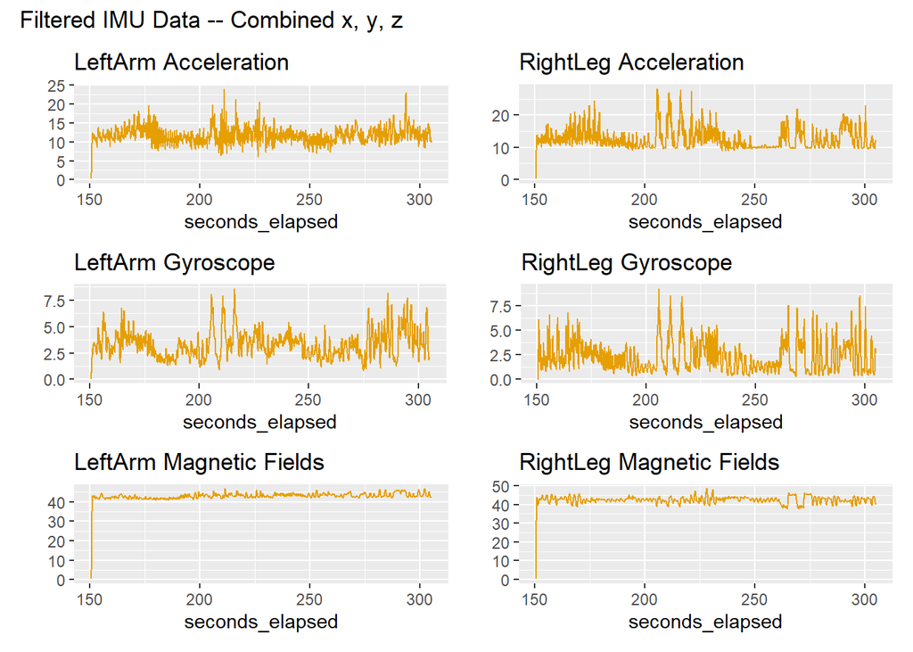

```r
lagfp = ggplot(data = LEFTARM) + geom_line(aes(x = seconds_elapsed, y = gyro_combinedf), color = "#E69F00") + labs(y = "",title = "LeftArm Gyroscope")

rlgfp = ggplot(data = RIGHTLEG) + geom_line(aes(x = seconds_elapsed, y = gyro_combinedf), color = "#E69F00") + labs(y = "",title = "RightLeg Gyroscope")

laafp = ggplot(data = LEFTARM) + geom_line(aes(x = seconds_elapsed, y = acc_combinedf), color = "#E69F00") + labs(y = "",title = "LeftArm Acceleration")

rlafp = ggplot(data = RIGHTLEG) + geom_line(aes(x = seconds_elapsed, y = acc_combinedf), color = "#E69F00") + labs(y = "",title = "RightLeg Acceleration")

lamfp = ggplot(data = LEFTARM) + geom_line(aes(x = seconds_elapsed, y = mag_combinedf), color = "#E69F00") + labs(y = "",title = "LeftArm Magnetic Fields")

rlmfp = ggplot(data = RIGHTLEG) + geom_line(aes(x = seconds_elapsed, y = mag_combinedf), color = "#E69F00") + labs(y = "",title = "RightLeg Magnetic Fields")

combinedfpatch = (laafp + rlafp)/(lagfp + rlgfp)/(lamfp + rlmfp)
combinedfpatch + plot_annotation(title = "Filtered IMU Data -- Combined x, y, z")
```

I want a comparison of unfiltered and filtered side-by-side

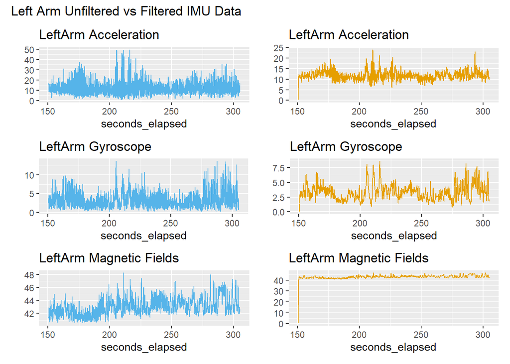

```r
#Unfortunately, I couldn't figure out how to put all 12 plots in one figure with an okay outcome. They're all so smushed, you can't see them. So instead I broke it up into Left Arm and Right Leg
combineduvflapatch = (laacp+laafp)/(lagcp+lagfp)/(lamcp+lamfp)
combineduvfrlpatch = (rlacp+rlafp)/(rlgcp+rlgfp)/(rlmcp+rlmfp)

combineduvflapatch + plot_annotation(title = "Left Arm Unfiltered vs Filtered IMU Data")
```

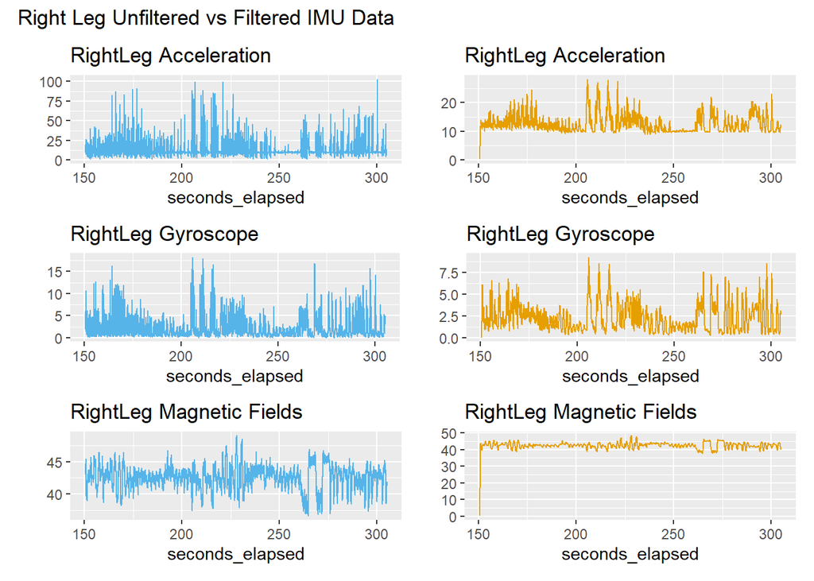

```r
combineduvfrlpatch + plot_annotation(title = "Right Leg Unfiltered vs Filtered IMU Data")
```

Now remove stuff all over again

```r
remove(laacp)
remove(laafp)
remove(lagcp)
remove(lagfp)
remove(lamcp)
remove(lamfp)
remove(rlacp)
remove(rlafp)
remove(rlgcp)
remove(rlgfp)
remove(rlmcp)
remove(rlmfp)
remove(cutoff)
remove(normal_cutoffarm)
remove(normal_cutoffleg)
remove(nyqarm)
remove(nyqleg)
remove(order)
remove(fsarm)
remove(fsleg)
remove(patch)
remove(combinedfpatch)
remove(combinedpatch)
remove(combineduvflapatch)
remove(combineduvfrlpatch)
remove(buttarm)
remove(buttleg)
```

Save relevant data:

```r
write.table(dance, here(path, "SavedFrames/TESTING_danceorder.txt"))
write.table(LEFTARM, here(path, "SavedFrames/LEFTARM_testingsubset.txt"))
write.table(RIGHTLEG, here(path, "SavedFrames/RIGHTLEG_testingsubset.txt"))
```